# Ejemplos de Estadística Inferencial con R

Salvador Díaz Maldonado

2025-01-10

Referencias:

https://www.sciencebase.gov/catalog/item/5bf30260e4b045bfcae0c205 https://rpubs.com/orlandoan/879142 Pruebas no paramétricas **(libro)**  
https://rpubs.com/diegomeza/inferencia_con_R  
https://estadistica-dma.ulpgc.es/cursoR4ULPGC/11-inferencia-MediaVar.html#el_test_de_wilcoxon-mann-whitneyhttps://www.geeksforgeeks.org/sign-test-in-r/ prueba de los signos  
https://rpubs.com/FabioScielzoOrtiz/Estadistica_Descriptiva_en_R  
https://osoramirez.github.io/R_Para_Biologos/index.html  
https://cienciadedatos.net/documentos/21_friedman_test

# PRUEBAS DE NORMALIDAD

## Ejemplo 1. Cont. (pruebas de normalidad)

Contrastar normalidad de las variables *x* y *y* del Ejemplo 1. de **Estadística Descriptica**.

### Datos

| x | y |
| --- | --- |
| 1.096 | 9.966 |
| -0.852 | 0.900 |
| 0.635 | 1.122 |
| 1.079 | 1.503 |
| -2.630 | 0.939 |
| 0.421 | 0.705 |
| 0.584 | 28.527 |
| -0.364 | 0.332 |
| 2.264 | 2.130 |
| -0.605 | 0.825 |

[output cut: 15 more lines]

Resumen estadístico de *x* :

```
##    Min. 1st Qu.  Median    Mean 3rd Qu.    Max.
## -2.6300 -0.5040  0.3950  0.1605  0.7180  2.2640
```

Resumen estadístico de *y* :

```
##    Min. 1st Qu.  Median    Mean 3rd Qu.    Max.
##   0.305   0.536   0.909   2.517   1.503  28.527
```

## Variable *x* :

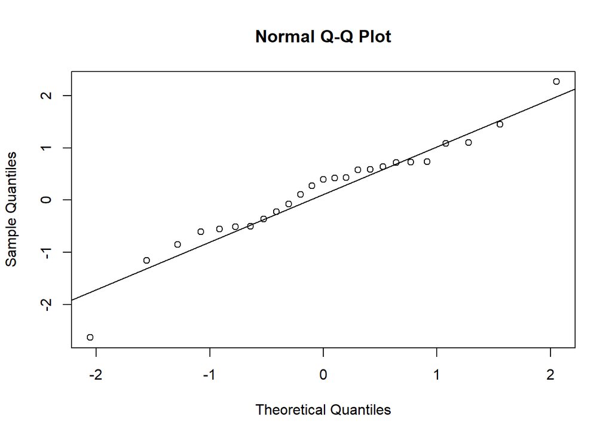

Para la variable *x* :

$H_{0}$: la muestra proviene de una población normalmente distribuida  
$H_{1}$: la muestra no proviene de una población normalmente distribuida

Rechazar la hipótesis nula si *p* ≤ $\alpha$=0.05 (para este caso)

### Prueba de Shapiro-Wilk

```
##
##  Shapiro-Wilk normality test
##
## data:  x
## W = 0.95404, p-value = 0.3086
```

Si *p*(0.3085891) > $\alpha$(0.05) no hay evidencia para rechazar la hipótesis nula, caso contrario, se rechaza.

### Prueba de Anderson-Darling

```
##
##  Anderson-Darling normality test
##
## data:  x
## A = 0.42854, p-value = 0.287
```

Si *p*(0.2869635) > $\alpha$(0.05) no hay evidencia para rechazar la hipótesis nula, caso contrario, se rechaza.

### Kolmogorov-Smirnov

```
##
##  Lilliefors (Kolmogorov-Smirnov) normality test
##
## data:  x
## D = 0.11849, p-value = 0.4862
```

Si *p*(0.4861748) > $\alpha$(0.05) no hay evidencia para rechazar la hipótesis nula, caso contrario, se rechaza.

## Variable *y*:

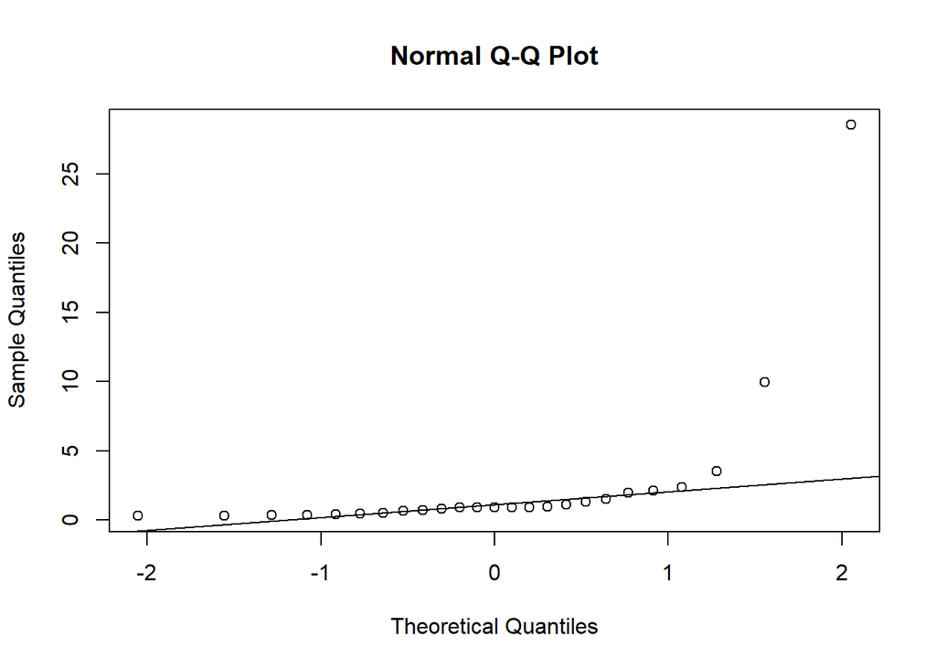

**Para la variable *y*:**

$H_{0}$: la muestra proviene de una población normalmente distribuida  
$H_{1}$: la muestra no proviene de una población normalmente distribuida

Rechazar la hipótesis nula si *p* ≤ $\alpha$=0.05 (para este caso)

### Prueba de Anderson-Darling

```
##
##  Anderson-Darling normality test
##
## data:  y
## A = 6.0176, p-value = 2.838e-15
```

Si *p*(2.8379344^{-15}) > $\alpha$(0.05) no hay evidencia para rechazar la hipótesis nula, caso contrario, se rechaza.

### Kolmogorov-Smirnov

```
##
##  Lilliefors (Kolmogorov-Smirnov) normality test
##
## data:  y
## D = 0.38965, p-value = 7.723e-11
```

Si *p*(7.722865^{-11}) > $\alpha$(0.05) no hay evidencia para rechazar la hipótesis nula, caso contrario, se rechaza.

# INTERVALOS DE CONFIANZA

## Ejemplo 1.(cont). Intervalos de confianza.

## Variable *x*:

*x* ordenada:

```
##  [1] -2.630 -1.154 -0.852 -0.605 -0.559 -0.509 -0.504 -0.364 -0.226 -0.076
## [11]  0.107  0.273  0.395  0.421  0.433  0.578  0.584  0.635  0.718  0.729
## [21]  0.730  1.079  1.096  1.449  2.264
```

### Intervalo de confianza simétrico para la media:

$\overline{x}-t_{(\alpha/2, n-1)}*\sqrt{s^2/n}≤\mu≤\overline{x}+t_{(\alpha/2, n-1)}*\sqrt{s^2/n}$

```
##
##  One Sample t-test
##
## data:  x
## t = 0.82748, df = 24, p-value = 0.4161
## alternative hypothesis: true mean is not equal to 0
## 95 percent confidence interval:
##  -0.2397899  0.5607499
## sample estimates:
## mean of x
##   0.16048
```

```
## [1] "Límite inferior = -0.23979 , Límite superior = 0.56075"
```

Por lo tanto, existe un 95% de probabilidad de que si se infiere que la media poblacional se encuentra entre los límites anteriores -0.2397899 a 0.5607499, se acierte.

## Variable *y* :

*y* ordenada:

```
##  [1]  0.305  0.332  0.347  0.368  0.408  0.452  0.536  0.642  0.705  0.825
## [11]  0.900  0.906  0.909  0.937  0.939  0.976  1.122  1.306  1.503  1.981
## [21]  2.130  2.378  3.528  9.966 28.527
```

### Intervalo de confianza asimétrico para la media.

Una forma de calcular el intervalo de confianza para estos casos, es transformando la variable a logarítmica, o con otra de las variadas transformaciones que existen y luego probar su normalidad.

### Transformando a *y* = ln(y)

Pruebas de normalidad:

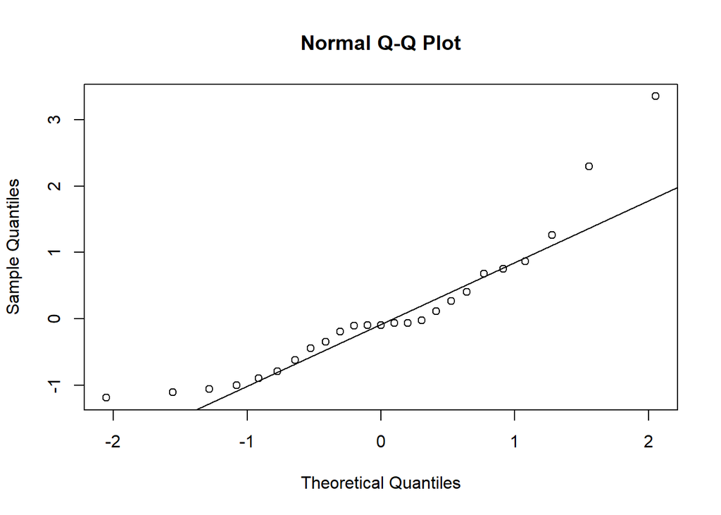

```
##
##  Shapiro-Wilk normality test
##
## data:  log(y)
## W = 0.86936, p-value = 0.0042
```

```
##
##  Anderson-Darling normality test
##
## data:  log(y)
## A = 0.95166, p-value = 0.01352
```

```
##
##  Lilliefors (Kolmogorov-Smirnov) normality test
##
## data:  log(y)
## D = 0.1778, p-value = 0.04032
```

Debido a que está en duda la normalidad de la variable *y*, y de su transformación logarítmica, otro estimador del intervalo de confianza sobre la media para datos asimétricos, lo proporciona el remuestreo (bootstrapping), que se desarrolla a continuación.

### Remuestreo para la media.

```
## BOOTSTRAP CONFIDENCE INTERVAL CALCULATIONS
## Based on 10000 bootstrap replicates
##
## CALL :
## boot.ci(boot.out = boot1, conf = 0.95, type = "perc")
##
## Intervals :
## Level     Percentile
## 95%   ( 0.937,  5.120 )
## Calculations and Intervals on Original Scale
```

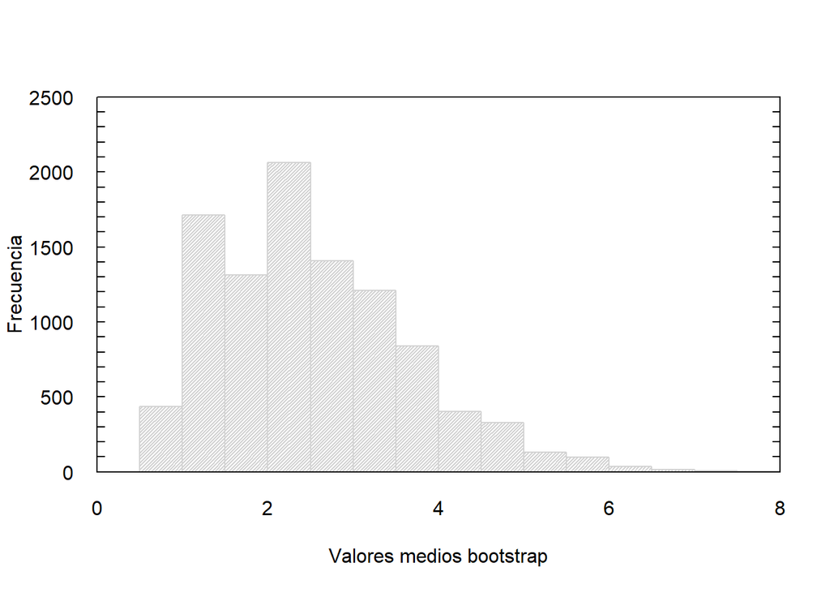

El histograma, a pesar de que se generaron medias de 10,000 muestras, aún se conserva asimétrico. Esto hace que sea recomendable incrementar el tamaño de la muestra *y*, lo cual puede ser complicado en la realidad. Una alternativa es trabajar con la mediana, en lugar de la media. Para ello se recomienda aplicar una función de distribución discreta, en este caso se aplicará la **binomial**. Entonces, debido a que no hay normalidad, se trabajará con el intervalo de confianza de la mediana, en lugar de la media.

### Función de distribución discreta Binomial.

Una función de distribución frecuentemente usada para datos asimétricos es la función discreta binomial.

### Intervalo de confianza de la mediana

```
## [1] "Rango inferior = 8 , Rango superior = 17"
```

```
## [1] "Límite inferior = 0.642 , Límite superior = 1.122"
```

```
## [1] "Probabilidad real para este rango: = 0.9567"
```

El resultado nos indica que está muy cerca de la probabilidad deseada de 0.95 (0.9567147). Por lo tanto, se podría decir que el intervalo estimado (0.642 a 1.122) es la mejor aproximación a un intervalo de confianza del 95 por ciento para la mediana.

### Con remuestreo (bootstrapping) para la mediana.

```
##
## Bootstrap Confidence Intervals of the Median of y
## Using boot package in R
##
## BOOTSTRAP CONFIDENCE INTERVAL CALCULATIONS
## Based on 10000 bootstrap replicates
##
## CALL :
## boot.ci(boot.out = B, conf = Conf, type = TYPE)
##
## Intervals :
## Level     Percentile
## 95%   ( 0.642,  1.306 )
## Calculations and Intervals on Original Scale
```

**Se observa que el intervalo de confianza asimétrico para la mediana aplicando la distribución binomial y el remuestreo es muy similar.**

## NOTA FINAL

En ocasiones, en la práctica, para facilitar la obtención de los intervalos de confianza de la media, se abrevia el cálculo de la normalidad mediante pruebas de bondad de ajuste, argumentando el soporte del teorema central del límite. Por lo que se aplica el intervalo de confianza simétrico para la media y no para la mediana, aunque los datos provengan de una población no normal.

Existen infinidad de ejemplos de demostración del teorema central del límite a partir de muestras generadas con funciones de distribución de probabilidad, es decir, aplicando estadística paramétrica. Sin embargo, existen casos, como el de la variable Y de este ejercicio, en que lo que se tiene es una muestra que no se ajusta o es muy complicado ajustarla a alguna FDP; aquí es donde se puede aplicar la técnica de remuestreo (bootstraping).

Para investigar un poco sobre lo anteriormente mencionado, se puede usar de nuevo la herramienta de remuestreo (bootstrapping).

Se va a aplicar solamente en la variable Y, la cual no proviene de una población con distribución normal.

Evaluando de nuevo normalidad:

```
##    Min. 1st Qu.  Median    Mean 3rd Qu.    Max.
##   0.305   0.536   0.909   2.517   1.503  28.527
```

```
##
##  Shapiro-Wilk normality test
##
## data:  y
## W = 0.38529, p-value = 3.287e-09
```

```
##
##  Anderson-Darling normality test
##
## data:  y
## A = 6.0176, p-value = 2.838e-15
```

```
##
##  Lilliefors (Kolmogorov-Smirnov) normality test
##
## data:  y
## D = 0.38965, p-value = 7.723e-11
```

A continuación, se usará el concepto de remuestreo (bootstrapping) para comprobar si el tamaño de la muestra (*n* = 25) es suficiente para considerar ese cálculo del intervalo de confianza simétrico.

Primero se generan N muestras con reemplazo de la muestra *y* (con remuestreo y no paramétrico), de tamaño *n* = 25, y se obtiene el promedio de las medias de cada muestra generada.

```
## [1] N muestras generadas con remuestreo = 5000 , Tamaño de cada muestra, n = 25
```

```
## [1] Media de las N medias muestrales = 2.535 , Desv. estándar de las medias muestrales = 1.1209
```

```
## [1] Media de la variable y = 2.5171 , Desv. estándar de la variable y = 5.7532
```

Se aprecia que la media de la muestra *y* es muy similar al promedio de las N muestras generadas con remuestreo.

En la siguiente gráfica se observa que existe disparidad con la distribución normal, por lo que se puede inferir que no existe normalidad en los datos generados por el promedio de las N medias muestrales.

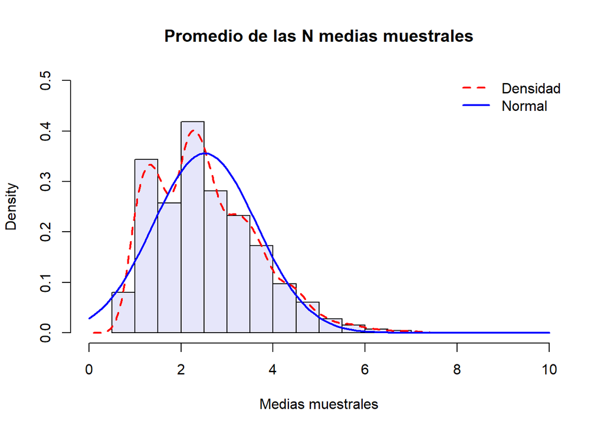

Pruebas de normalidad::

```
##
##  Shapiro-Wilk normality test
##
## data:  MediasBoots
## W = 0.95628, p-value < 2.2e-16
```

```
##
##  Lilliefors (Kolmogorov-Smirnov) normality test
##
## data:  MediasBoots
## D = 0.065659, p-value < 2.2e-16
```

Se confirma lo que se observa en la gráfica anterior, no existe normalidad usando el boostrap. Entonces, podría concluirse que el tamaño de la muestra Y debe incrementarse.

Se aclara que el ejemplo se ejecutó con diferentes tamaños de número de muestras, pero la desviación estándar no disminuyó. Es decir, aparentemente el punto para lograr la normalidad, es incrementar el tamaño de la muestra Y.

# INTERVALOS DE PREDICCIÓN

## Ejemplo 1. Cont (Intervalos de predicción)

Calcular el intervalo de predicción para un nuevo valor de las variables *x* y *y* del ejemplo 1.

## Variable *x*:

Ya se comprobó anteriormente la normalidad de la muestra *x*, por lo que se aplica la siguiente ecuación para intervalos de predicción simétricos:

$\bar{x}\mp t_{(\alpha /2-1)}\bullet \sqrt{s^{2}+\left ( s^{2}/n \right )}$

```
## [1] Límite inferior del IP = -1.8805 Límite superior del IP = 2.2015
```

## Variable *y* :

Para el caso de la muestra *y*, se estimó que no cumple con normalidad, por lo que estimará el intervalo de predicción, considerándolo como no paramétrico de dos colas.

Entonces, suponiendo $\alpha$ = 0.05, se calculará evaluando sus cuantiles.

```
## [1] 0.909
```

```
## [1] Límite inferior del IP = 0.305 Límite superior del IP = 28.527
```

```
## [1] Mediana de la muestra = 0.909
```

Los resultados del intervalo de predicción son 0.305 y 28.527. Nótese el alto grado de asimetría en este caso. La mediana es 0.909. Por lo tanto, una nueva observación menor a 0.305 ppb o mayor a 28.527 puede considerarse como proveniente de una distribución diferente con un nivel de significancia del 5 por ciento (α = 0.05).

# PRUEBAS PARA UNA MUESTRA

## Ejemplo 2.

En un muestreo de diferentes marcas de jugo de tomate enlatado, se analizó la vitamina C y se encontraron, por cada 100 g de jugo, las siguientes cantidades de vitamina C (en mg) por observación.

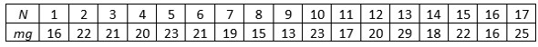

Ejemplo 2

También, se sabe que la media poblacional de vitamina C en las diferentes marcas es de $\mu$ = 18.5 mg/100 g, ¿Es significativa la diferencia?

**1)** Seleccionar la prueba apropiada.

1. Primero se establece si los datos provienen de una población normal. Esto se determina a continuación:

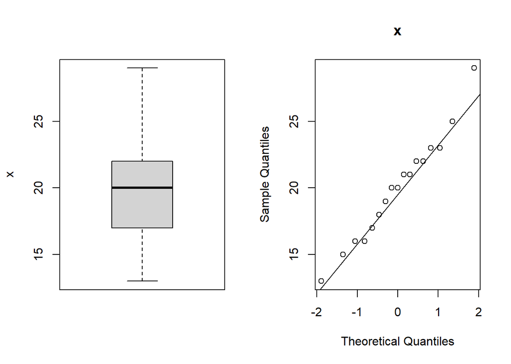

```
##
##  Shapiro-Wilk normality test
##
## data:  x
## W = 0.98008, p-value = 0.9578
```

```
##
##  Anderson-Darling normality test
##
## data:  x
## A = 0.17919, p-value = 0.9018
```

```
##
##  Lilliefors (Kolmogorov-Smirnov) normality test
##
## data:  x
## D = 0.10809, p-value = 0.8618
```

Se infiere que la muestra proviene de una población normal. Por lo tanto, se usa una prueba paramétrica.

**2)** Las hipótesis son:

H0: $\mu$ = $\bar{x}$ o $\mu$ - $\bar{x}$ = 0

H1: $\mu$ $\neq$ 0 o $\mu$ - $\bar{x}$ $\neq$ 0

**3)** El valor de la tasa de error aceptable es $\alpha$ = 0.05.

**4)** Calcular la prueba estadística.

Se selecciona la prueba *t* para una muestra.

**5)** Ahora se aplica la prueba de t Student

```
##
##  One Sample t-test
##
## data:  x
## t = 1.5522, df = 16, p-value = 0.1402
## alternative hypothesis: true mean is not equal to 18.5
## 95 percent confidence interval:
##  17.95144 22.04856
## sample estimates:
## mean of x
##        20
```

**6)** Rechazar la hipótesis nula si *p* ≤ $\alpha$.

Debido a que el valor de *p*(0.1401589) > $\alpha$(0.05), no hay evidencia para rechazar H0. La diferencia entre la media muestral, 20, y la media poblacional, 18.5, (= 1.5), no es significativa.

## Ejemplo 3.

Un criador de pollos sabe por experiencia que el peso de los pollos de cinco meses es 4.35 libras. Los pesos siguen una distribución normal. Para tratar de aumentar el peso de dichas aves se le agrega un aditivo al alimento. En una muestra de pollos de cinco meses se obtuvieron los siguientes pesos (en libras).

| *i* | 1 | 2 | 3 | 4 | 5 | 6 | 7 | 8 | 9 | 10 |
| --- | --- | --- | --- | --- | --- | --- | --- | --- | --- | --- |
| Peso | 4.41 | 4.37 | 4.33 | 4.35 | 4.30 | 4.39 | 4.36 | 4.38 | 4.40 | 4.39 |

¿Con un nivel de significancia de 0.01, ¿el aditivo ha aumentado el peso medio de los pollos?

**1)** Seleccionar la prueba apropiada.

1. Prueba paramétrica o no paramétrica.

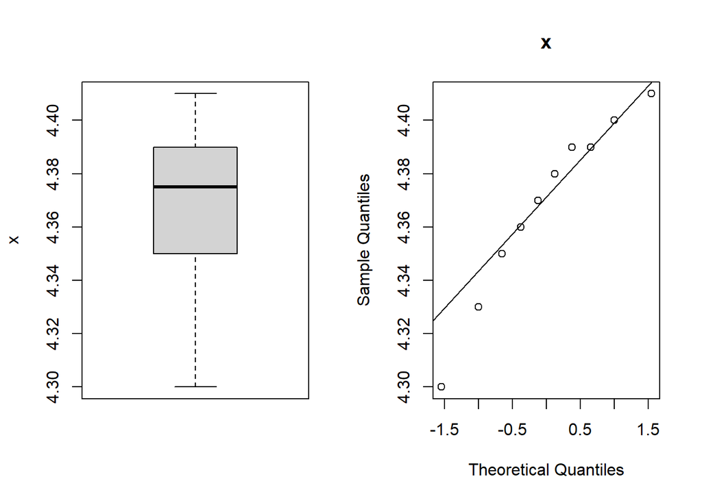

```
##
##  Shapiro-Wilk normality test
##
## data:  x
## W = 0.94213, p-value = 0.577
```

```
##
##  Anderson-Darling normality test
##
## data:  x
## A = 0.27213, p-value = 0.5864
```

```
##
##  Lilliefors (Kolmogorov-Smirnov) normality test
##
## data:  x
## D = 0.14165, p-value = 0.8242
```

Se infiere que la muestra proviene de una población normal. Por lo tanto, se usa una prueba paramétrica.

2. Objetivo de la prueba. Verificar si el aditivo ha aumentado el peso promedio de los pollos.

**2)** Las hipótesis son:

Suponiendo que *x* es la variable de la población y *y* la variable de la muestra. Entonces la hipótesis nula será:

$H_{0}$: $\mu =\mu _{0}$

Por otro lado, como se desea ver si la media poblacional, $\mu _{0}$, aumenta con el aditivo, la hipótesis alternativa será:

H1: $\mu >\mu _{0}$

**3)** El valor de la tasa de error aceptable es $\alpha$ = 0.01.

**4)** Calcular la prueba estadística.

```
##
##  One Sample t-test
##
## data:  x
## t = 1.6777, df = 9, p-value = 0.06386
## alternative hypothesis: true mean is greater than 4.35
## 99 percent confidence interval:
##  4.337729      Inf
## sample estimates:
## mean of x
##     4.368
```

**5)** Calcular el valor de *p*.

El valor de *p* es 0.0638588

**6)** Rechazar la hipótesis nula si *p* ≤ $\alpha$.

Por lo tanto, si *p*(0.0638588) > $\alpha$(0.01), no hay evidencia para rechazar $H_{0}$. La diferencia de ($\mu _{0}$-$\mu$) = (4.368-4.35)= 0.018 no es significativa.

## Ejemplo 4.

Un estudiante de zootecnia analizó el fósforo en el suero sanguíneo de ganado vacuno, estudiando una muestra al azar de 9 animales. Los valores de fósforo en mg/10cc de suero sanguíneo fueron los siguientes:

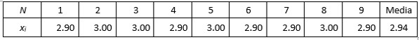

Ejemplo 4

La teoría y la experiencia indican que la media poblacional $\mu$ en una población no deficiente debe ser de 7 mg/100 cc. ¿Son deficientes en fósforo los animales muestreados? O, ¿Es significativa la diferencia entre las medias poblacional y muestral?

**1)** Seleccionar la prueba apropiada.

```
a) Prueba paramétrica o no paramétrica.
```

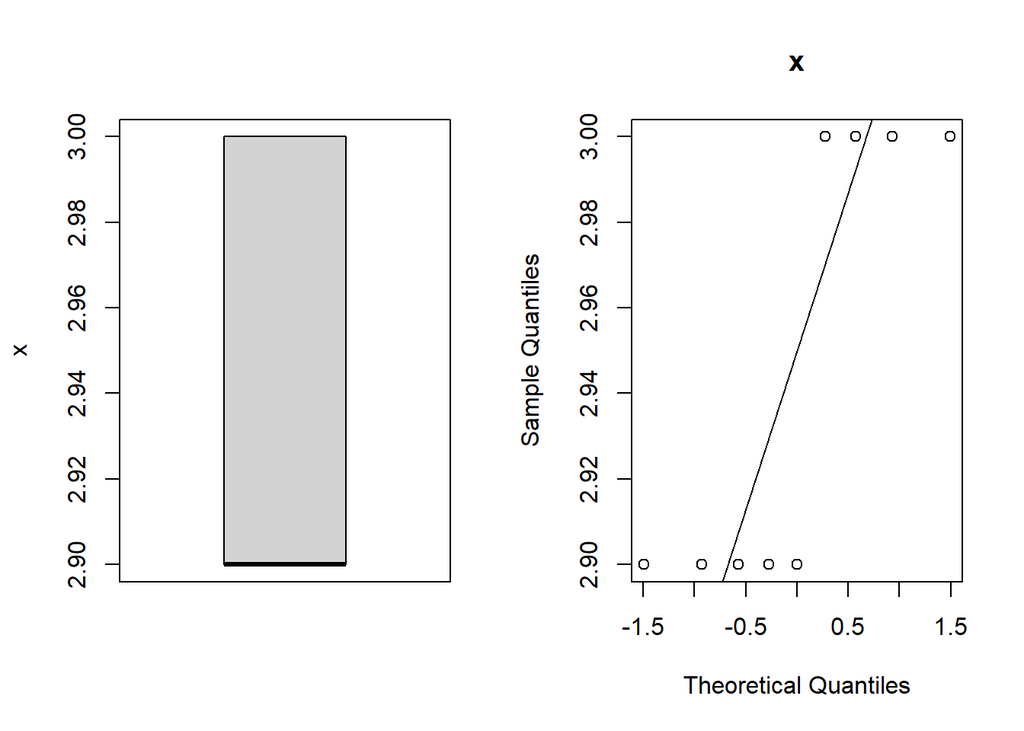

```
##
##  Shapiro-Wilk normality test
##
## data:  x
## W = 0.65474, p-value = 0.0004194
```

```
##
##  Anderson-Darling normality test
##
## data:  x
## A = 1.4876, p-value = 0.000306
```

```
##
##  Lilliefors (Kolmogorov-Smirnov) normality test
##
## data:  x
## D = 0.35602, p-value = 0.001628
```

Se observa que todas las pruebas coinciden en que no existe normalidad. Por lo tanto, se recomienda aplicar una prueba no paramétrica, en donde no interviene la *media poblacional*, sino la *mediana poblacional*. Entonces, se recomienda aplicar otra prueba no paramétrica, diferente a la *t* Student.

2. Objetivo de la prueba. Es significativa la diferencia entre las medianas poblacional y muestral.
2. Establecer las hipótesis nula y alternativa.

H0: Mediana muestral = Mediana poblacional

H1: Mediana muestral $\neq$ Mediana poblacional

Debido a que el único dato que se tiene de la población es la media, no es posible continuar el procedimiento de solución porque se carece precisamente de su mediana.

## Ejemplo 5.

Se tienen los siguientes datos de rendimiento unitario de algunos pozos en un acuífero sin fracturas. Determinar si pertenecen a una población con mediana de 0.04458.

[figure not shown]

Ejemplo 5

1. Seleccionar la prueba apropiada.
   1. Prueba paramétrica o no paramétrica.

Comprobando normalidad:

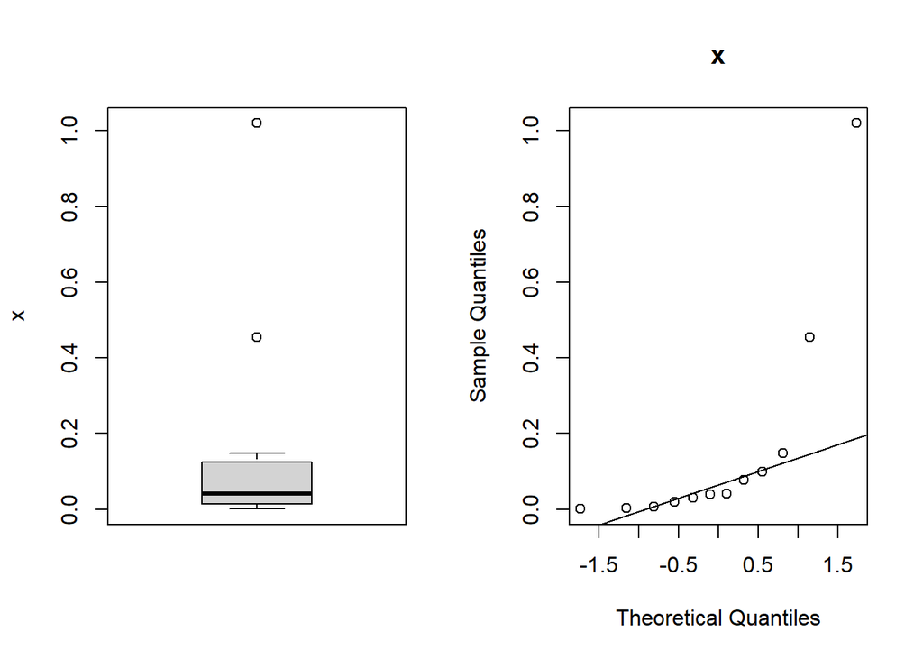

```
##
##  Shapiro-Wilk normality test
##
## data:  x
## W = 0.58963, p-value = 8.801e-05
```

```
##
##  Anderson-Darling normality test
##
## data:  x
## A = 2.1036, p-value = 9.555e-06
```

```
##
##  Lilliefors (Kolmogorov-Smirnov) normality test
##
## data:  x
## D = 0.35052, p-value = 0.0002252
```

No hay evidencia para aceptar la normalidad en estos datos. Se aplicará la prueba de signos no paramétrica para muestras pequeñas.

2. Objetivo de la prueba. Verificar si la muestra *x* proviene de una población con mediana de 0.04458.
2. Establecer las hipótesis nula y alternativa.

   $H_{0}$: Mediana de la muestra = mediana de la población

   $H_{1}$: Mediana de la muestra $\neq$ mediana de la población
3. Decidir una tasa de error aceptable.

   $\alpha$ = 0.05
4. Calcular la prueba estadística.
5. Calcular el valor de *p*.

```
##
##  One-sample Sign-Test
##
## data:  x
## s = 5, p-value = 0.7744
## alternative hypothesis: true median is not equal to 0.04458
## 95 percent confidence interval:
##  0.008382727 0.143788182
## sample estimates:
## median of x
##      0.0405
##
## Achieved and Interpolated Confidence Intervals:
##
##                   Conf.Level L.E.pt U.E.pt
## Lower Achieved CI     0.8540 0.0200 0.1000
## Interpolated CI       0.9500 0.0084 0.1438
## Upper Achieved CI     0.9614 0.0070 0.1490
```

Se obtiene *p* = 0.7744141

6. Rechazar la hipótesis nula si *p* ≤ $\alpha$.

**También, usando la prueba binomial para muestras pequeñas:**

```
## [1] 0.007 0.100
```

Valores de *x* entre los cuales se encuentra la mediana: [0.007 y 0.1]. Entonces, el rango en donde se encuentra es: [3 a 9].

```
##
##  Exact binomial test
##
## data:  rangos[1] and rangos[2]
## number of successes = 3, number of trials = 9, p-value = 0.5078
## alternative hypothesis: true probability of success is not equal to 0.5
## 95 percent confidence interval:
##  0.07485463 0.70070494
## sample estimates:
## probability of success
##              0.3333333
```

Se obtiene *p* = 0.5078125

```
##
##  Wilcoxon rank sum exact test
##
## data:  x and md
## W = 5, p-value = 0.9231
## alternative hypothesis: true location shift is not equal to 0
```

Se obtiene *p* = 0.9230769

Confirmándose si, o no, existe evidencia de que la muestra *x* pertenece a una población con mediana igual a 0.04458.

## Ejemplo 6.

Finalmente, se analizarán los datos *x* y *y* del Ejemplo 1.

| x | y |
| --- | --- |
| 1.096 | 9.966 |
| -0.852 | 0.900 |
| 0.635 | 1.122 |
| 1.079 | 1.503 |
| -2.630 | 0.939 |
| 0.421 | 0.705 |
| 0.584 | 28.527 |
| -0.364 | 0.332 |
| 2.264 | 2.130 |
| -0.605 | 0.825 |

[output cut: 15 more lines]

Para la variable *x* ya se comprobó que existe normalidad, entonces, realizar los cálculos considerando que la media poblacional es de aproximadamente 0.204. Por otro lado, para la variable Y se comprobó la no normalidad, y se supondrá una mediana poblacional aproximada de 1.074.

### Variable *x* :

1. Seleccionar la prueba apropiada.
   1. Prueba paramétrica o no paramétrica.

   Prueba paramétrica.
   2. Objetivo de la prueba. Realizar una prueba de diferencias de medias entre la muestra X y la población de la cual proviene.
2. Establecer las hipótesis nula y alternativa.

   $H_{0}$: $\bar{x}=\mu_{x}$  
   $H_{1}$: $\bar{x}\neq\mu_{x}$
3. Decidir una tasa de error aceptable.

   $\alpha$ = 0.05
4. Calcular la prueba estadística (t Student).

```
##
##  One Sample t-test
##
## data:  x
## t = -0.2244, df = 24, p-value = 0.8243
## alternative hypothesis: true mean is not equal to 0.204
## 95 percent confidence interval:
##  -0.2397899  0.5607499
## sample estimates:
## mean of x
##   0.16048
```

Se obtiene *p* = 0.8243449

6. Rechazar la hipótesis nula si *p* ≤ $\alpha$.

Si *p*(0.8243449) > $\alpha$(0.05) existe evidencia de que la muestra X pertenece a una población con media igual a 0.204. Si no, se rechaza $H_{0}$.

### Variable *y* :

1. Seleccionar la prueba apropiada.
   1. Prueba paramétrica o no paramétrica.

   Prueba no paramétrica (no normalidad obtenida en el Ejemplo 1).
   2. Objetivo de la prueba. Realizar una prueba de diferencias de medianas entre la muestra *y* y la población de la cual proviene.
2. Establecer las hipótesis nula y alternativa.

   $H_{0}$: Mediana de y = mediana de la población

   $H_{1}$: Mediana de y $\neq$ mediana de la población
3. Decidir una tasa de error aceptable.

   $\alpha$ = 0.05
4. Seleccionar la prueba estadística.

Prueba de Wilcoxon

5. Calcular el valor de *p*

```
##
##  Wilcoxon signed rank exact test
##
## data:  y
## V = 155, p-value = 0.8532
## alternative hypothesis: true location is not equal to 1.074
```

6. Rechazar la hipótesis nula si *p* ≤ $\alpha$.

# DOS MUESTRAS INDEPENDIENTES

*Los ejemplos siguientes comparan dos grupos independientes de datos para determinar si un grupo tiende a contener valores mayores que el otro. Los datos son independientes cuando no están emparejados, es decir, cuando no no hay emparejamientos de datos entre la observación 1 del grupo 1 y la observación 1 del grupo 2, y así sucesivamente.Los datos también deben ser independientes en el sentido de que los dos grupos representan condiciones diferentes (ni las observaciones ni la población que representan deben estar en ambos grupos).*

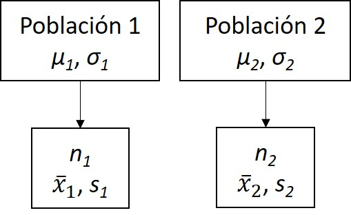

Dos muestras independientes

## Ejemplo 7.

Un investigador ha obtenido la talla, en cm., de 20 niños de 5 años de edad, de dos condiciones socioeconómicas contrastantes (alta y baja). Considera que ambos grupos de población tienen estaturas significativamente diferentes

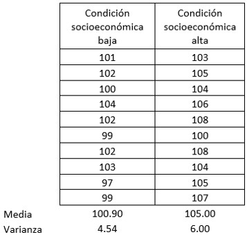

Ejemplo 7

1. Seleccionar la prueba apropiada.
   1. Prueba paramétrica o no paramétrica.

Para condición socioeconómica baja:

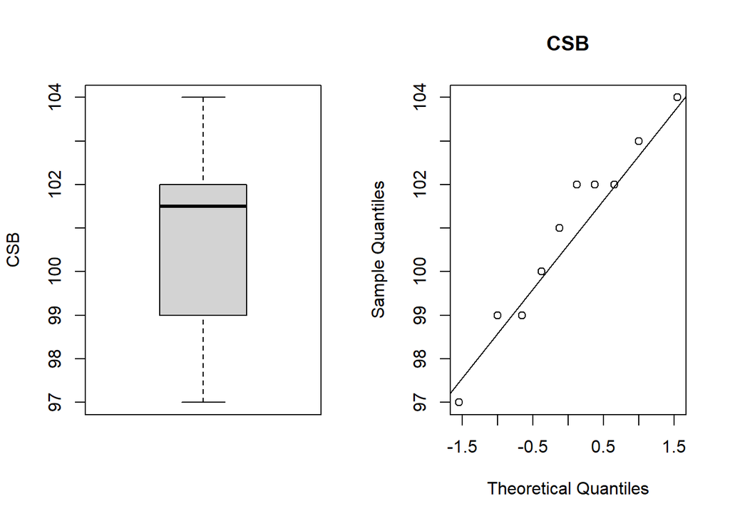

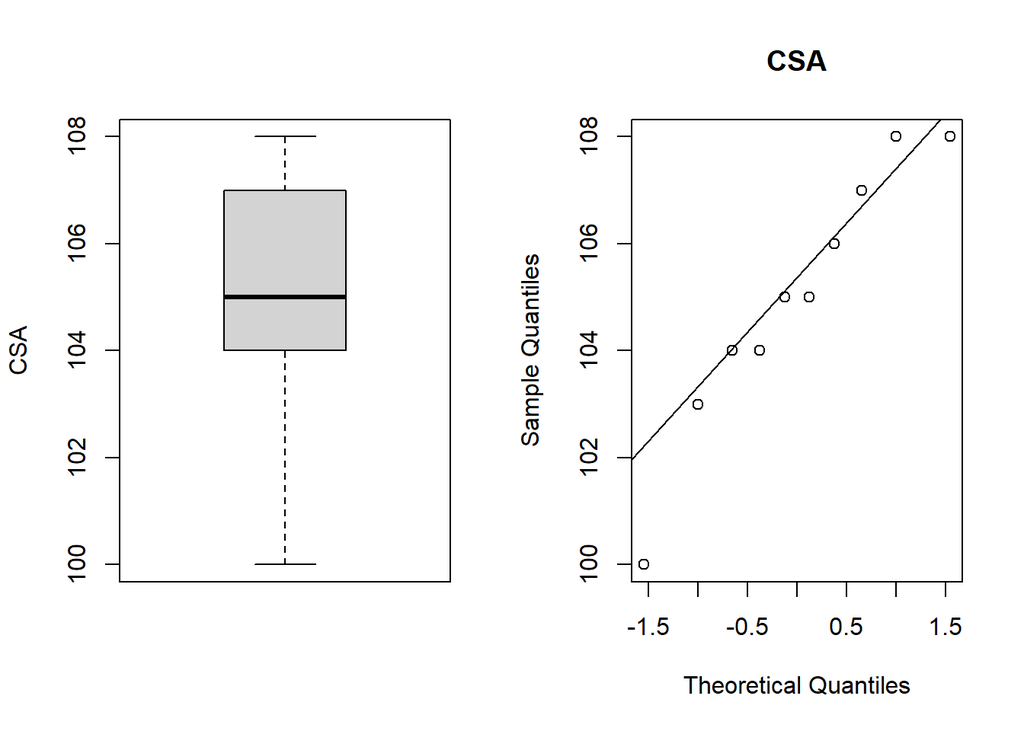

```
##
##  Shapiro-Wilk normality test
##
## data:  CSB
## W = 0.95832, p-value = 0.7665
```

```
##
##  Anderson-Darling normality test
##
## data:  CSB
## A = 0.26669, p-value = 0.6042
```

```
##
##  Lilliefors (Kolmogorov-Smirnov) normality test
##
## data:  CSB
## D = 0.19707, p-value = 0.3307
```

Y para condición socioeconómica alta:

```
##
##  Shapiro-Wilk normality test
##
## data:  CSA
## W = 0.93963, p-value = 0.5489
```

```
##
##  Anderson-Darling normality test
##
## data:  CSA
## A = 0.25949, p-value = 0.6289
```

```
##
##  Lilliefors (Kolmogorov-Smirnov) normality test
##
## data:  CSA
## D = 0.14155, p-value = 0.825
```

Como se aprecia, ambas muestras provienen de una distribución normal. Por otro lado, Verificando si ambas muestras tiene igual varianza. Aplicando Fisher:

```
##
##  F test to compare two variances
##
## data:  CSB and CSA
## F = 0.75741, num df = 9, denom df = 9, p-value = 0.6857
## alternative hypothesis: true ratio of variances is not equal to 1
## 95 percent confidence interval:
##  0.1881293 3.0493178
## sample estimates:
## ratio of variances
##          0.7574074
```

Se concluye que como *p*(0.6856572) > $\alpha$(0.05), no se debe rechazar $H_{0}$, que las varianzas de las dos muestras son iguales. Caso contrario, se rechaza $H_{0}$.

La prueba será paramétrica.

```
b) Objetivo: Diferencia entre las medias de ambas muestras independientes.
```

2. Establecer las hipótesis nula y alternativa.

   $H_{1}$: $\mu_{1} = \mu _{2}$ o $\mu_{1}-\mu _{2}$ = 0

   $H_{1}$: $\mu_{1} \neq \mu _{2}$ o $\mu_{1}-\mu _{2} \neq$ 0
3. Decidir una tasa de error aceptable.

   $\alpha$ = 0.05
4. Seleccionar la prueba estadística de los datos.

Entonces, se aplica la prueba *t* para dos muestras independientes y con varianzas iguales.

5. Calcular el valor de *p*.

```
##
##  Two Sample t-test
##
## data:  CSB and CSA
## t = -3.9927, df = 18, p-value = 0.0008535
## alternative hypothesis: true difference in means is not equal to 0
## 95 percent confidence interval:
##  -6.257356 -1.942644
## sample estimates:
## mean of x mean of y
##     100.9     105.0
```

6. Rechazar la hipótesis nula si *p* ≤ $\alpha$.

Si *p*(8.5350267^{-4}) > $\alpha$(0.05) se acepta $H_{0}$. Caso contrario, se rechaza $H_{0}$.

Es decir, sí existe una diferencia significativa entre la estatura de las dos condiciones socioeconómicas con un nivel de confianza del 0.95 %.

## Ejemplo 8.

En la tabla se presenta el peso de cabritos de dos razas diferentes en kg, al mes de nacidos.

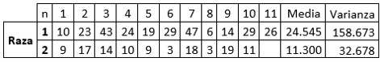

Ejemplo 8

Determinar si existe una diferencia significativa entre el peso de ambas razas 1 y 2.

1. Seleccionar la prueba apropiada.
   1. Prueba paramétrica o no paramétrica.

Para la raza 1:

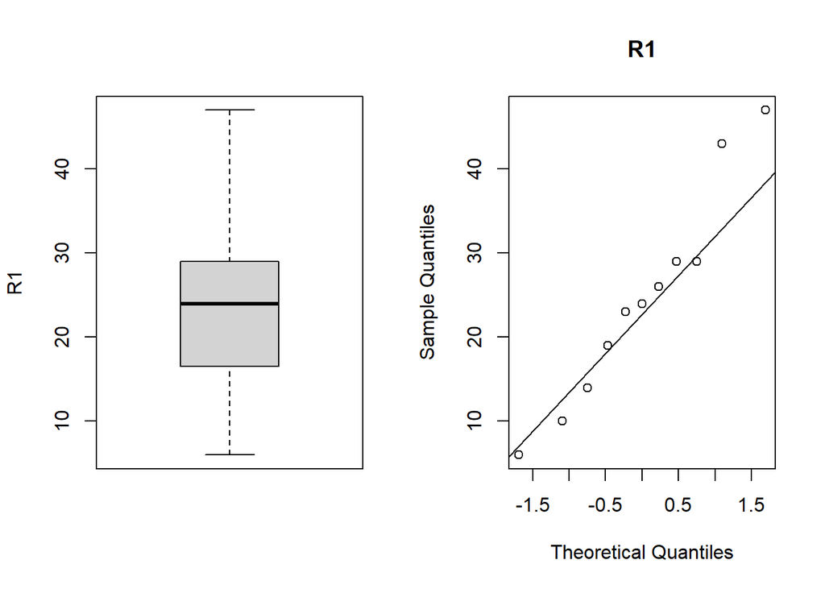

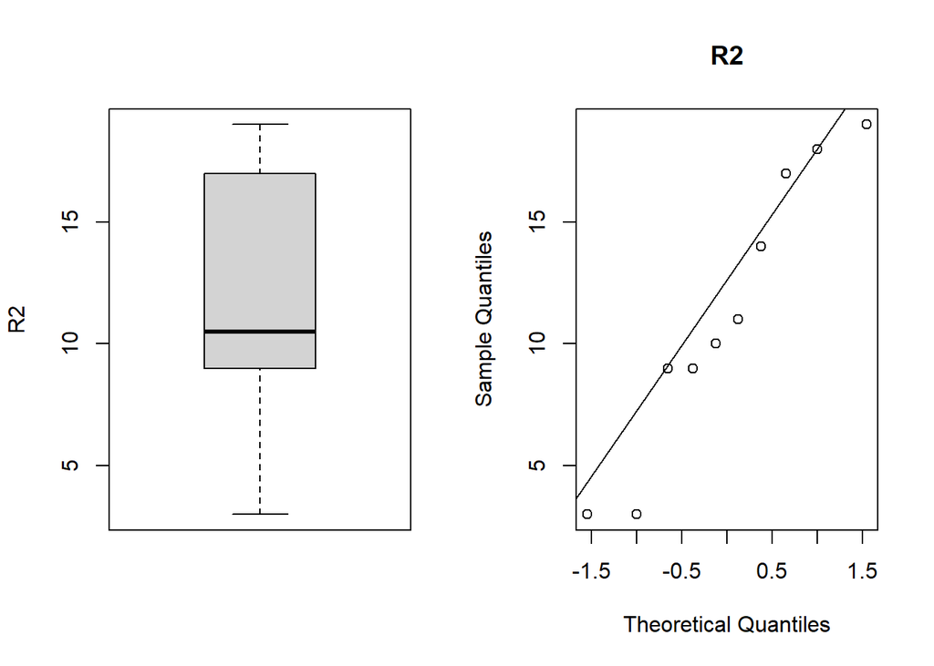

```
##
##  Shapiro-Wilk normality test
##
## data:  R1
## W = 0.95528, p-value = 0.7118
```

```
##
##  Anderson-Darling normality test
##
## data:  R1
## A = 0.25004, p-value = 0.6719
```

```
##
##  Lilliefors (Kolmogorov-Smirnov) normality test
##
## data:  R1
## D = 0.17999, p-value = 0.4087
```

Para la raza 2:

```
##
##  Shapiro-Wilk normality test
##
## data:  R2
## W = 0.92378, p-value = 0.3896
```

```
##
##  Anderson-Darling normality test
##
## data:  R2
## A = 0.30962, p-value = 0.5017
```

```
##
##  Lilliefors (Kolmogorov-Smirnov) normality test
##
## data:  R2
## D = 0.14371, p-value = 0.808
```

Se comprueba que ambas muestras provienen de una distribución normal. Para seleccionar la prueba estadística se calculará también la diferencia de varianzas.

Aplicando Fisher:

```
##
##  F test to compare two variances
##
## data:  R1 and R2
## F = 4.8557, num df = 10, denom df = 9, p-value = 0.02608
## alternative hypothesis: true ratio of variances is not equal to 1
## 95 percent confidence interval:
##   1.224985 18.349421
## sample estimates:
## ratio of variances
##           4.855677
```

Si *p* (0.0260842) < $\alpha$(0.05), no existe evidencia para aceptar $H_{0}$ de que la varianza de las dos muestras son iguales. Caso contrario, se acepta $H_{0}$.

Entonces, se resolverá considerando que las dos muestras tienen comportamiento normal y desigualdad de varianzas.

2. Objetivo: Diferencia entre las medias de ambas muestras independientes.
2. Establecer las hipótesis nula y alternativa.

   $H_{0}$: $\mu_{1} = \mu _{2}$ o $\mu_{1}-\mu _{2}$ = 0

   $H_{1}$: $\mu_{1} \neq \mu _{2}$ o $\mu_{1}-\mu _{2} \neq$ 0
3. Decidir una tasa de error aceptable.

   $\alpha$ = 0.05
4. Seleccionar la prueba estadística de los datos.

5. Calcular el valor de *p*.

```
##
##  Welch Two Sample t-test
##
## data:  R1 and R2
## t = 3.149, df = 14.232, p-value = 0.006985
## alternative hypothesis: true difference in means is not equal to 0
## 95 percent confidence interval:
##   4.237739 22.253170
## sample estimates:
## mean of x mean of y
##  24.54545  11.30000
```

6. Rechazar la hipótesis nula si *p* ≤ $\alpha$.

   Si p(0.0069854) < $\alpha$(0.05) se rechaza $H_{0}$. Es decir, si existe una diferencia significativa entre ambas razas con un nivel de confianza del 0.95 %.

## Ejemplo 9.

Se desea comparar la calidad del agua precipitada entre dos sitios con diferente uso de suelo. Se solicita aplicar una prueba para determinar si uno de sus constituyentes químicos difiere significativamente ($\alpha$ = 0.05) entre los sitios residencial e industrial.

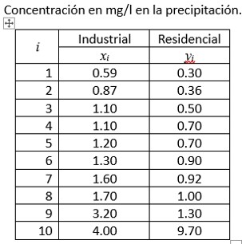

Ejemplo 9

1. Seleccionar la prueba apropiada.
   1. Prueba paramétrica o no paramétrica.

Usando R para comprobar normalidad:

• *Industrial*:

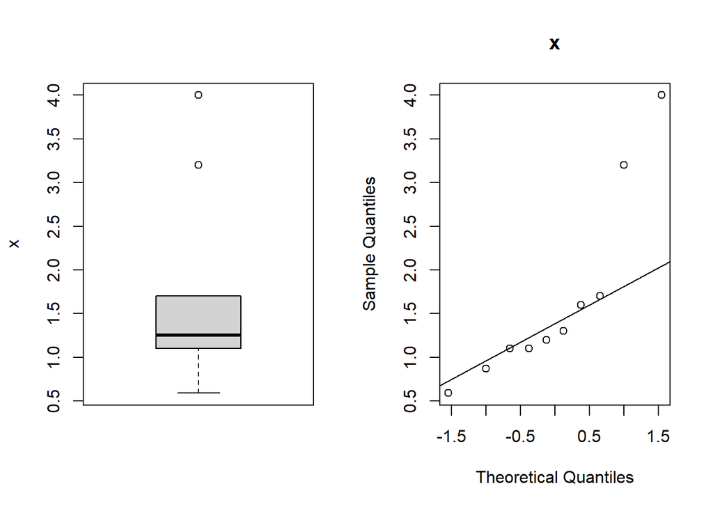

```
##
##  Shapiro-Wilk normality test
##
## data:  x
## W = 0.80346, p-value = 0.01597
```

```
##
##  Anderson-Darling normality test
##
## data:  x
## A = 0.91991, p-value = 0.01166
```

```
##
##  Lilliefors (Kolmogorov-Smirnov) normality test
##
## data:  x
## D = 0.2875, p-value = 0.01879
```

• *Residencial*:

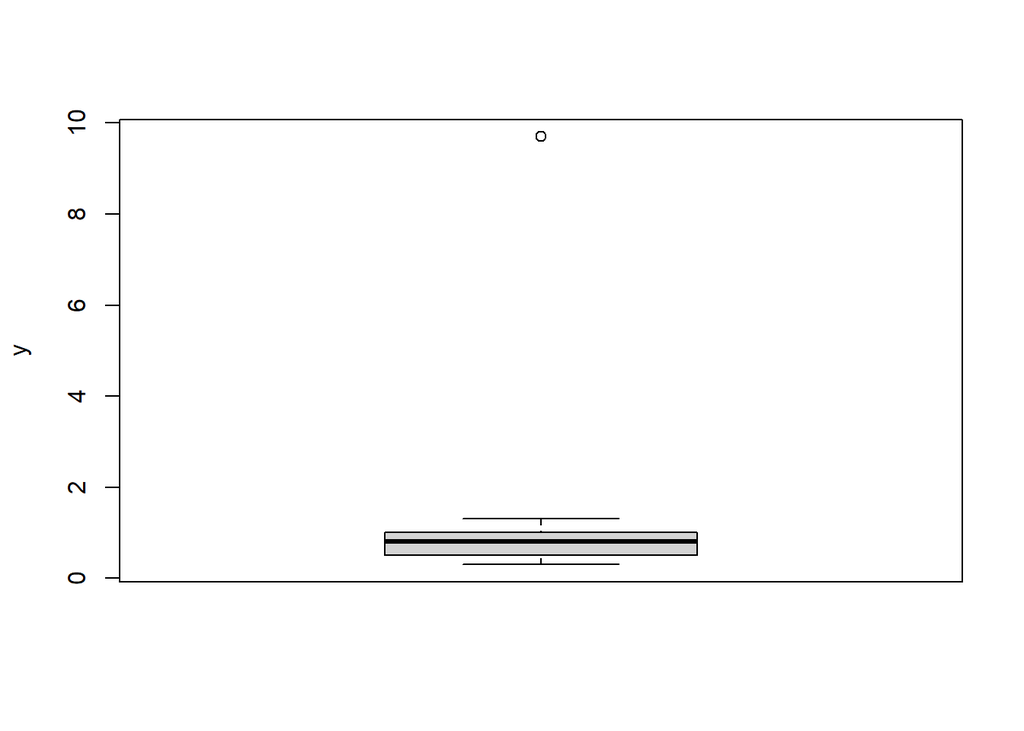

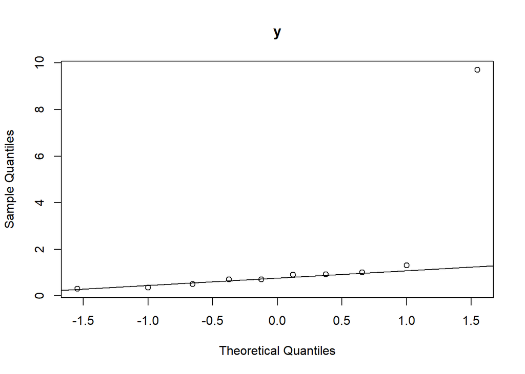

```
##
##  Shapiro-Wilk normality test
##
## data:  y
## W = 0.46754, p-value = 1.517e-06
```

```
##
##  Anderson-Darling normality test
##
## data:  y
## A = 2.473, p-value = 7.798e-07
```

```
##
##  Lilliefors (Kolmogorov-Smirnov) normality test
##
## data:  y
## D = 0.44722, p-value = 2.814e-06
```

Tanto la muestra *x* como la muestra *y* se suponen no normales, ya que todas las pruebas confirman no normalidad. Aparentemente, dos puntos disparados provocan la no normalidad en *x* y uno en *y*.

Entonces se debe resolver para no paramétrico.

2. Objetivo. Verificar si las medianas de ambas muestras son iguales.
2. Establecer las hipótesis nula y alternativa.

Entonces, una muestra tiende a producir valores mayores que la otra muestra. Por lo que la hipótesis nula propuesta es:

$H_{0}$: Mediana de concentración industrial = Mediana concentración residencial

$H_{1}$: Mediana de concentración industrial $\neq$ Mediana concentración residencial.

3. Decidir una tasa de error aceptable.

   $\alpha$ = 0.05
4. Seleccionar la prueba estadística de los datos. ( *Wilcoxon* )

Aplicar la prueba de suma de rangos de Wilcoxon:

5. Calcular el valor de *p*

```
##
##  Wilcoxon rank sum test with continuity correction
##
## data:  x and y
## W = 76.5, p-value = 0.04911
## alternative hypothesis: true location shift is not equal to 0
```

6. Rechazar la hipótesis nula si *p* ≤ $\alpha$.

Notar que el valor de *p* = 0.04911 es muy cercano al valor de $\alpha$ = 0.05. Esto confirma que no debería aceptarse $H_{0}$, pero por muy poco margen.

## Ejemplo 10.

En la siguiente tabla se presentan los valores del peso de 80 niños y 80 niñas al nacer, habiéndose muestreados 20 de cada sexo en 4 hospitales.

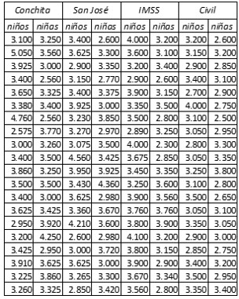

Ejemplo 10

Siendo dos muestras independientes (no relacionadas, asociadas o correlacionadas) determinar si la diferencia de sus medias, o medianas, es altamente significativa a favor de los niños.

1. Seleccionar la prueba apropiada.
1. Prueba paramétrica o no paramétrica.

Para los niños:

| x | y |
| --- | --- |
| 3.100 | 3.250 |
| 5.050 | 3.560 |
| 3.925 | 3.000 |
| 3.400 | 2.560 |
| 3.650 | 3.325 |
| 3.380 | 3.400 |
| 4.760 | 2.560 |
| 2.575 | 3.770 |
| 3.000 | 3.260 |
| 3.400 | 3.500 |

[output cut: 70 more lines]

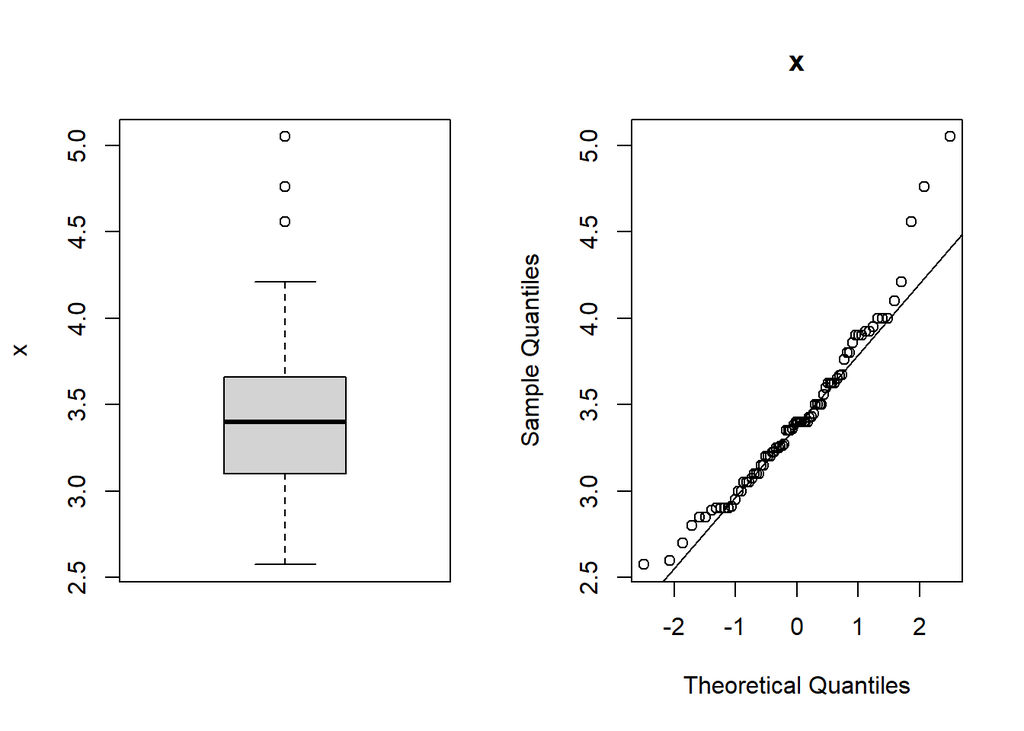

```
##
##  Shapiro-Wilk normality test
##
## data:  x
## W = 0.95241, p-value = 0.004746
```

```
##
##  Anderson-Darling normality test
##
## data:  x
## A = 0.77421, p-value = 0.04252
```

```
##
##  Lilliefors (Kolmogorov-Smirnov) normality test
##
## data:  x
## D = 0.096388, p-value = 0.06341
```

Como no hay normalidad en los pesos de los niños se aplica no paramétrico.

Y para las niñas:

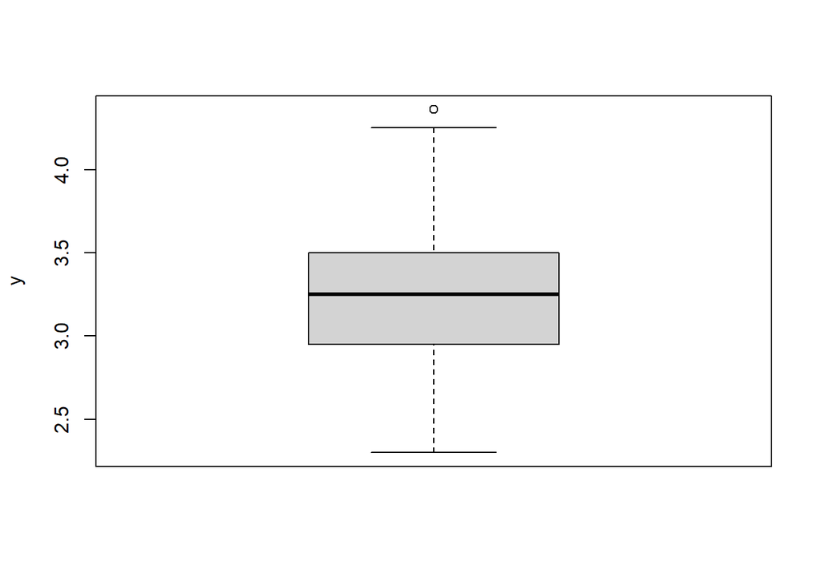

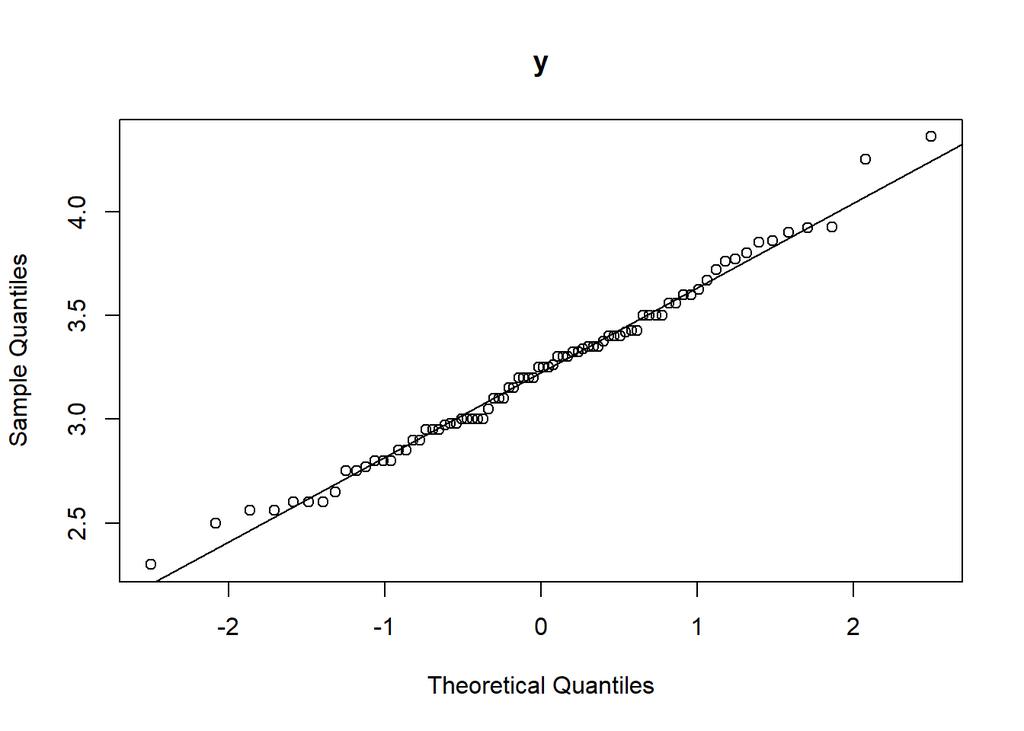

```
##
##  Shapiro-Wilk normality test
##
## data:  y
## W = 0.98982, p-value = 0.7837
```

```
##
##  Anderson-Darling normality test
##
## data:  y
## A = 0.22096, p-value = 0.8268
```

```
##
##  Lilliefors (Kolmogorov-Smirnov) normality test
##
## data:  y
## D = 0.072897, p-value = 0.3675
```

Existe normalidad en los pesos de las niñas. Análisis paramétrico.

Entonces, para aplicar análisis paramétrico se usaría t Student, pero en esta prueba debe haber normalidad en ambas muestras. Como no es el caso, se aplicará análisis no paramétrico, como se sugiere en el paso 4 con la prueba suma de rangos, Mann- Whitney.

2. Establecer las hipótesis nula y alternativa.

   $H_{0}$: Mediana de pesos de niños = Mediana de pesos de niñas

   $H_{1}$: Mediana de pesos de niños > Mediana de pesos de niñas
3. Definir una tasa de error aceptable.

$\alpha$ = 0.01 (altamente significativa)

4. Calcular la prueba estadística de los datos. (Prueba de Mann- Whitney)

```
##
##  Wilcoxon rank sum test with continuity correction
##
## data:  x and y
## W = 3957, p-value = 0.0049
## alternative hypothesis: true location shift is greater than 0
```

5. Calcular el valor de *p*.
6. Rechazar la hipótesis nula si *p* ≤ $\alpha$.

Como p(0.0049001) < $\alpha$(0.01), se rechaza $H_{0}$.

Entonces, como *p* < $\alpha$ se rechaza H0 y no se rechaza $H_{1}$. Un riesgo de error con una probabilidad menor de 1% de rechazar una cosa cierta.

La mediana del peso de los niños es mayor que la mediana de las niñas, con $\alpha$ = 0.01.

# DOS MUESTRAS DEPENDIENTES

https://datatab.es/tutorial/dependent-and-independent-samples

https://espanol.libretexts.org/Estadisticas/Estadisticas_Introductorias/Libro%3A_Estad%C3%ADstica_inferencial_y_probabilidad_-_Un_enfoque_hol%C3%ADstico_(Geraghty)/11%3A_Inferencia_de_dos_poblaciones/11.01%3A_Muestreo_independiente_vs._dependiente

*Las muestras dependientes, también conocidas como muestras pareadas, hacen referencia a un método estadístico en el que se comparan dos grupos relacionados. Las muestras dependientes se caracterizan por el hecho de que las mediciones realizadas no son independientes entre sí.*

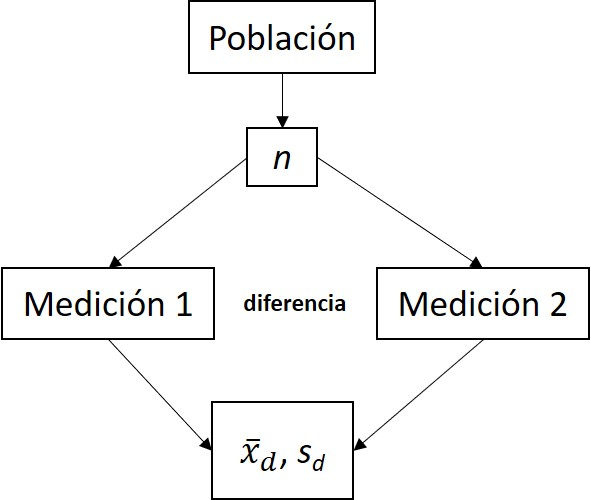

Dos muestras dependientes

## Ejemplo 11.

En la tabla se presentan la altura y la longitud, en cm, de los brazos extendidos, de extremo a extremo de los dedos medios, de once estudiantes.

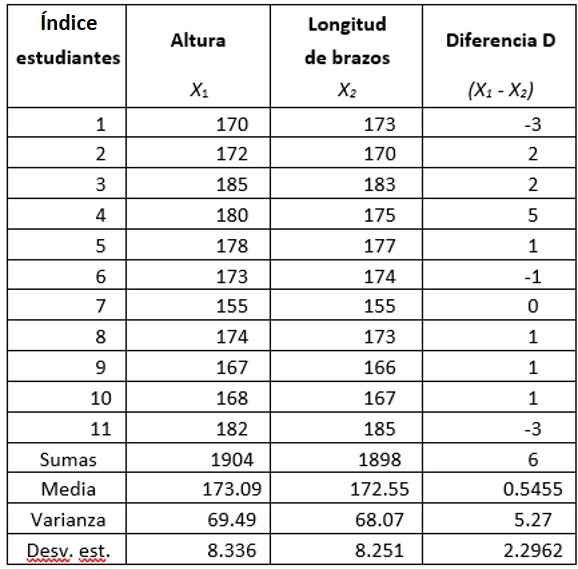

Ejemplo 11

1. Seleccionar la prueba apropiada.
   1. Prueba paramétrica o no paramétrica.

```
##
##  Shapiro-Wilk normality test
##
## data:  h
## W = 0.95575, p-value = 0.7177
```

[output not shown]

```
##
##  Lilliefors (Kolmogorov-Smirnov) normality test
##
## data:  h
## D = 0.14158, p-value = 0.778
```

Existe normalidad en la altura.

Para la variable longitud de brazos:

```
##
##  Shapiro-Wilk normality test
##
## data:  l
## W = 0.95392, p-value = 0.6943
```

```
##
##  Anderson-Darling normality test
##
## data:  l
## A = 0.2788, p-value = 0.5742
```

```
##
##  Lilliefors (Kolmogorov-Smirnov) normality test
##
## data:  l
## D = 0.15833, p-value = 0.6166
```

Existe normalidad.

Por otro lado, Verificando la igualdad de varianzas:

```
##
##  F test to compare two variances
##
## data:  h and l
## F = 1.0208, num df = 10, denom df = 10, p-value = 0.9746
## alternative hypothesis: true ratio of variances is not equal to 1
## 95 percent confidence interval:
##  0.2746544 3.7942250
## sample estimates:
## ratio of variances
##           1.020833
```

Se acepta la igualdad de varianzas ya que *p*(0.9746331) > $\alpha$(0.05)

Entonces es análisis paramétrico.

2. Objetivo de la prueba. Determinar si la altura promedio del hombre determina la longitud de sus brazos.
2. Establecer las hipótesis nula y alternativa.

   $H_{0}$: $\mu _{x_{1}}$ = $\mu _{x_{2}}$ o $\mu _{x_{1}}$ - $\mu _{x_{2}}$ = 0

   $\alpha$ = 0.05
4. Calcular la prueba estadística de los datos.

```
##
##  Paired t-test
##
## data:  h and l
## t = 0.78784, df = 10, p-value = 0.7755
## alternative hypothesis: true mean difference is less than 0
## 95 percent confidence interval:
##      -Inf 1.800299
## sample estimates:
## mean difference
##       0.5454545
```

6. Rechazar la hipótesis nula si *p* ≤ $\alpha$.

   Como p(0.7754687) > $\alpha$(0.05) no se rechaza la hipótesis nula.

La altura promedio del hombre es igual al promedio de la longitud de punta a punta de sus dedos medios entre sus brazos extendidos.

## Ejemplo 12.

A las personas que sufren de alta presión sanguínea, se les recomienda seguir una dieta libre de sal. Se quiere realizar un estudio para comprobar si esta dieta es efectivamente ventajosa. Para el estudio se analizó una muestra de 8 personas y se tomó la presión antes de empezar la dieta y dos semanas después. Los resultados obtenidos fueron:

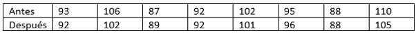

Ejemplo 12

1. Seleccionar la prueba apropiada.
   1. Prueba paramétrica o no paramétrica.

Para “Antes”:

```
##
##  Shapiro-Wilk normality test
##
## data:  A
## W = 0.92249, p-value = 0.4504
```

```
##
##  Anderson-Darling normality test
##
## data:  A
## A = 0.30644, p-value = 0.483
```

```
##
##  Lilliefors (Kolmogorov-Smirnov) normality test
##
## data:  A
## D = 0.20125, p-value = 0.4434
```

Se cumple la hipótesis de normalidad.

Para “Después”:

```
##
##  Shapiro-Wilk normality test
##
## data:  D
## W = 0.91801, p-value = 0.4139
```

```
##
##  Anderson-Darling normality test
##
## data:  D
## A = 0.32644, p-value = 0.4289
```

```
##
##  Lilliefors (Kolmogorov-Smirnov) normality test
##
## data:  D
## D = 0.21473, p-value = 0.3408
```

Se cumple la hipótesis de normalidad.

Para la diferencia:

```
##
##  Shapiro-Wilk normality test
##
## data:  dif
## W = 0.91462, p-value = 0.3877
```

```
##
##  Anderson-Darling normality test
##
## data:  dif
## A = 0.3851, p-value = 0.3002
```

```
##
##  Lilliefors (Kolmogorov-Smirnov) normality test
##
## data:  dif
## D = 0.25, p-value = 0.1486
```

Se cumple normalidad.

Verificando la igualdad de varianzas:

```
##
##  F test to compare two variances
##
## data:  A and D
## F = 1.7486, num df = 7, denom df = 7, p-value = 0.4783
## alternative hypothesis: true ratio of variances is not equal to 1
## 95 percent confidence interval:
##  0.3500722 8.7339930
## sample estimates:
## ratio of variances
##           1.748579
```

Como se aprecia, se acepta la hipótesis nula de igualdad de varianzas, ya que *p*(0.4783315) > $\alpha$(0.05).

Análisis paramétrico.

2. Objetivo. Verificar si la media poblacional de ambas muestras provienen de la misma población. Diferencia entre las medias poblacionales.
2. Establecer las hipótesis nula y alternativa.

   $H_{0}$: $\mu _{antes}$ = $\mu _{después}$

   $H_{1}$: $\mu _{antes}$ > $\mu _{después}$
3. Decidir una taza de error aceptable.

   $\alpha$ = 0.05
4. Calcular la prueba estadística de los datos.

```
##
##  Paired t-test
##
## data:  A and D
## t = 1.1832, df = 7, p-value = 0.1377
## alternative hypothesis: true mean difference is greater than 0
## 95 percent confidence interval:
##  -0.6012112        Inf
## sample estimates:
## mean difference
##               1
```

5. Calcular el valor de *p*

*p* = 0.1376728

6. Rechazar la hipótesis nula si *p* ≤ $\alpha$.

Como p(0.1376728) > $\alpha$(0.05) se acepta la hipótesis nula. Es decir, las medias poblacionales provienen de la misma población, por lo que no hay diferencia significativa, es decir, no existe evidencia significativa que realmente hacer dieta sea ventajoso.

## Ejemplo 13.

Se registraron cuentas de ninfas de mosca en 12 pequeños arroyos de bajo caudal aguas arriba y aguas abajo de emisores industriales. La ninfa de mosca es un indicador de la buena calidad del agua. La cuestión a considerar es si por los efluentes de los emisores disminuyeron el número de ninfas en los arroyos de esa región. Se establece como aceptable un tipo de riesgo a nivel α de 0.01.

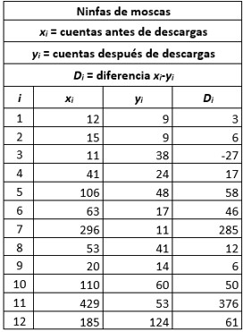

Ejemplo 13

1. Seleccionar la prueba asociada.
1. Prueba paramétrica o no paramétrica.

Pruebas de normalidad para $x_{i}$:

```
##
##  Shapiro-Wilk normality test
##
## data:  x
## W = 0.78041, p-value = 0.005658
```

```
##
##  Anderson-Darling normality test
##
## data:  x
## A = 1.0531, p-value = 0.005719
```

```
##
##  Lilliefors (Kolmogorov-Smirnov) normality test
##
## data:  x
## D = 0.25533, p-value = 0.02969
```

Pruebas de normalidad para $y_{i}$:

```
##
##  Shapiro-Wilk normality test
##
## data:  y
## W = 0.80853, p-value = 0.01173
```

```
##
##  Anderson-Darling normality test
##
## data:  y
## A = 0.75765, p-value = 0.03483
```

```
##
##  Lilliefors (Kolmogorov-Smirnov) normality test
##
## data:  y
## D = 0.19383, p-value = 0.2436
```

Resulta similar a la anterior, por lo que se acepta la no normalidad también.

Entonces será una prueba no paramétrica.

2. Objetivo. Analizar la relación probabilística de las cuentas aguas arriba y aguas debajo de los emisores.
2. Establecer las hipótesis nula y alternativa.

La hipótesis nula $H_{0}$ es que las cuentas aguas arriba del canal son igualmente probables de ser mayores o menores que las cuentas de aguas abajo de la cascada. La hipótesis alternativa $H_{1}$ es que las cuentas aguas abajo de la cascada son menores, por efecto de los efluentes, en cuyo caso S+ sería mayor.

$H_{0}$: Prob [ *x* > *y* ] = 0.5, probabilidad de que *x* sea mayor que *y* es 0.5.

$H_{1}$: Prob [ *x* > *y* ] > 0.5 (Prueba de una cola. *x* tiende a ser mayor que *y* )

3. Decidir una tasa de error aceptable.

   $\alpha$ = 0.01
4. Calcular la prueba estadística de los datos. (**Prueba de los signos**)

```
##
##  Dependent-samples Sign-Test
##
## data:  x and y
## S = 11, p-value = 0.003174
## alternative hypothesis: true median difference is greater than 0
## 99 percent confidence interval:
##  4.270909      Inf
## sample estimates:
## median of x-y
##          31.5
##
## Achieved and Interpolated Confidence Intervals:
##
##                   Conf.Level L.E.pt U.E.pt
## Lower Achieved CI     0.9807 6.0000    Inf
## Interpolated CI       0.9900 4.2709    Inf
## Upper Achieved CI     0.9968 3.0000    Inf
```

5. Calcular el valor de *p*.

*p* = 0.0031738

6. Rechazar la hipótesis nula si *p* ≤ $\alpha$.

Entonces, como *p*(0.0031738) < $\alpha$(0.01) se rechaza $H_{0}$. Es decir, se rechaza que la probabilidad de las cuentas aguas arriba sean menores que la probabilidad de las cuentas aguas abajo del canal con un nivel de confianza de 0.99%. Y se acepta $H_{1}$, que las cuentas aguas arriba tienden a ser mayores que aguas abajo.